# GPS Data Events and Work Order Correlations

Anne Schwenker

December 11, 2018

## Introduction

-6000 vehicles with gps units installed report activity every 2 minutes. This activity is collected and stored for analysis. These activities have events associated that are reported by the device -The most frequent event is “6 - timed update” -An operations team is met with the challenge of managing these 6000 devices and coordinating with a 3rd party vendor for installations and repairs. The team wishes you to use the reported events to make inferences regarding the state of the device, and to determine if a repair has been performed so that they may know independent of a report from the 3rd party installation & repair vendor.

## The Question

Is there a relationship between reported gps events and instances of work performed

## The data

- GPS Data records recorded every 2 minutes with lat lon, vehicle attributes and an event subtype id
- Work Order Data a record for every work order stating the date the work order closed
- These two sources were manipulated to find count of event by day and count of repair type by day and joined together based on the date. Final data used for analysis was a record for each day with variables of each event and its count

Event Counts by Day

| date | X1 | X106 | X110 | X111 | X112 | X113 | X117 | X12 | X13 | X14 | X144 | X15 | X16 | X161 | X163 | X164 | X166 | X17 | X174 | X175 | X176 | X177 | X19 | X198 | X199 | X2 | X20 | X21 | X22 | … |
| --- | --- | --- | --- | --- | --- | --- | --- | --- | --- | --- | --- | --- | --- | --- | --- | --- | --- | --- | --- | --- | --- | --- | --- | --- | --- | --- | --- | --- | --- | --- |
| 2018-10-11 | 1678 | 753 | 0 | 1 | 0 | 0 | 3 | 1488 | 1732 | 4556 | 0 | 784 | 1052 | 1551 | 13691 | 13846 | 1281 | 1050 | 211 | 1554 | 13866 | 41 | 1612 | 0 | 0 | 1669 | 800 | 794 | 1405 | … |
| 2018-10-12 | 1857 | 838 | 1 | 0 | 0 | 0 | 0 | 1564 | 1804 | 4562 | 0 | 863 | 946 | 1582 | 13867 | 14066 | 1279 | 946 | 212 | 1588 | 14079 | 59 | 1630 | 0 | 0 | 1857 | 789 | 815 | 1412 | … |
| 2018-10-13 | 427 | 193 | 0 | 0 | 0 | 0 | 0 | 128 | 317 | 195 | 0 | 183 | 4 | 0 | 0 | 0 | 0 | 4 | 1 | 0 | 0 | 21 | 4 | 0 | 0 | 428 | 1 | 10 | 67 | … |
| 2018-10-15 | 1497 | 1262 | 0 | 0 | 0 | 0 | 12 | 1757 | 1814 | 4561 | 0 | 1317 | 675 | 1571 | 13681 | 13897 | 1279 | 676 | 200 | 1579 | 13912 | 59 | 1615 | 0 | 0 | 1494 | 789 | 779 | 1406 | … |
| 2018-10-22 | 1535 | 1598 | 0 | 0 | 0 | 0 | 0 | 1789 | 1817 | 4635 | 0 | 1726 | 680 | 1543 | 13857 | 14074 | 1274 | 678 | 207 | 1549 | 14077 | 61 | 1678 | 0 | 0 | 1535 | 815 | 815 | 1378 | … |

## The Study

- this study was observational based on a sample of days where gps events and work orders occurred
- The larger population would be the future days with work orders and events occuring through which assumptions could be made about work done based on gps events occurring

## Exploratory Data Analysis

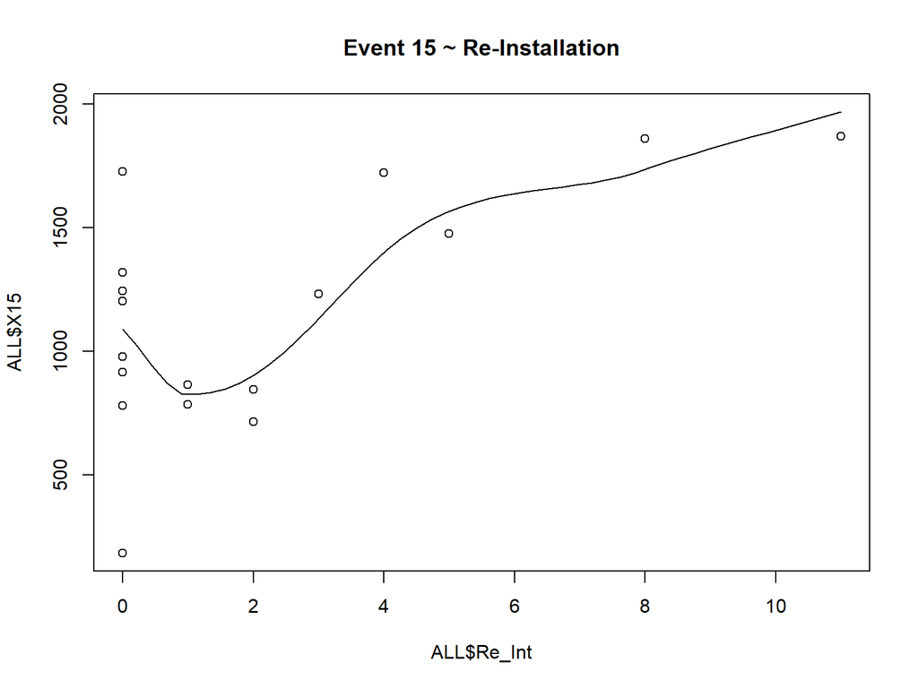

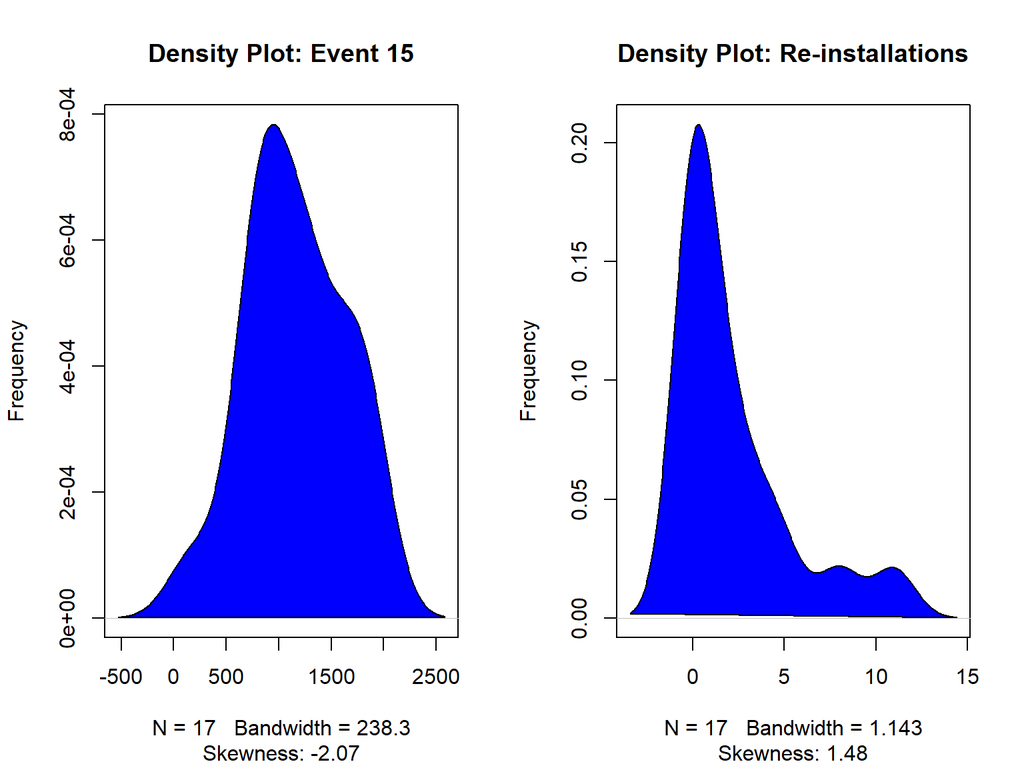

```
## [1] 0.6372818
```

```
##
## Call:
## lm(formula = X15 ~ Re_Int, data = ALL)
##
## Residuals:
##     Min      1Q  Median      3Q     Max
## -774.13 -186.88   -5.38  245.87  768.87
##
## Coefficients:
##             Estimate Std. Error t value Pr(>|t|)
## (Intercept)   957.13     109.94   8.706 2.99e-07 ***
## Re_Int         92.75      28.96   3.203  0.00593 **
## ---
## Signif. codes:  0 '***' 0.001 '**' 0.01 '*' 0.05 '.' 0.1 ' ' 1
##
## Residual standard error: 371.4 on 15 degrees of freedom
## Multiple R-squared:  0.4061, Adjusted R-squared:  0.3665
## F-statistic: 10.26 on 1 and 15 DF,  p-value: 0.00593
```

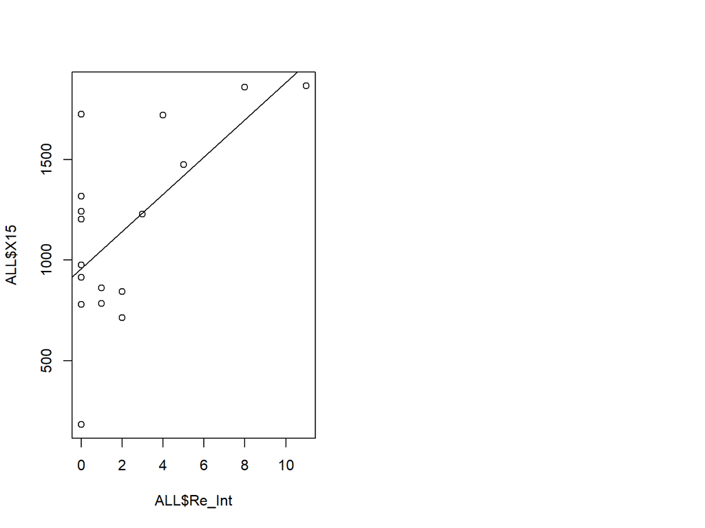

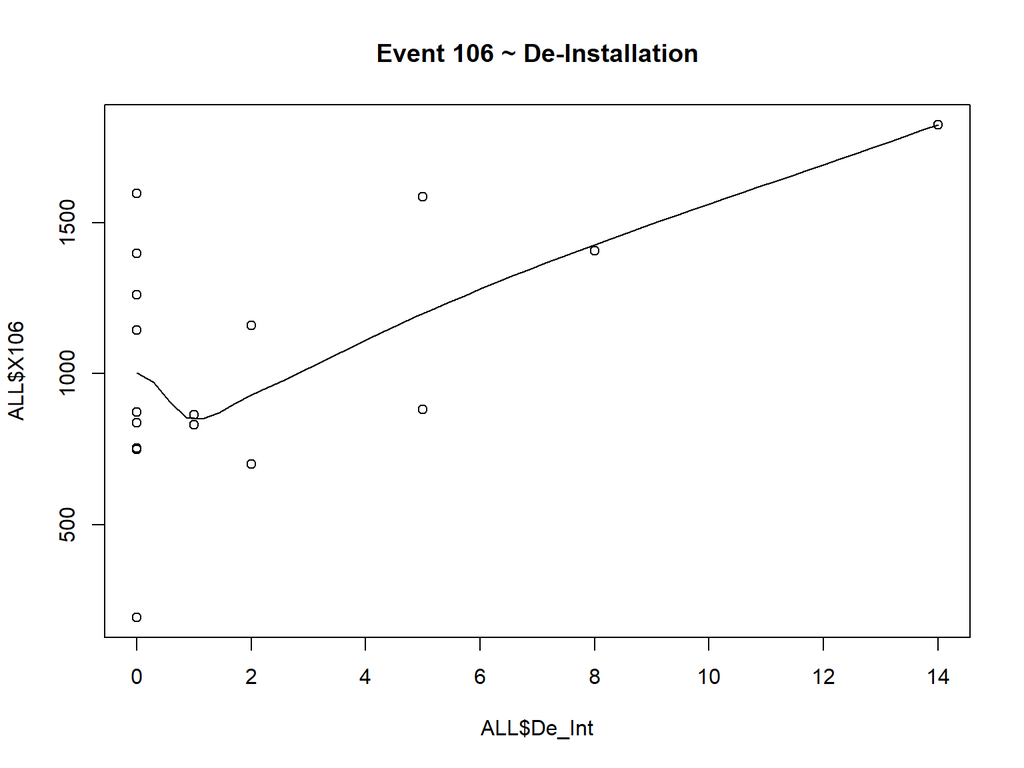

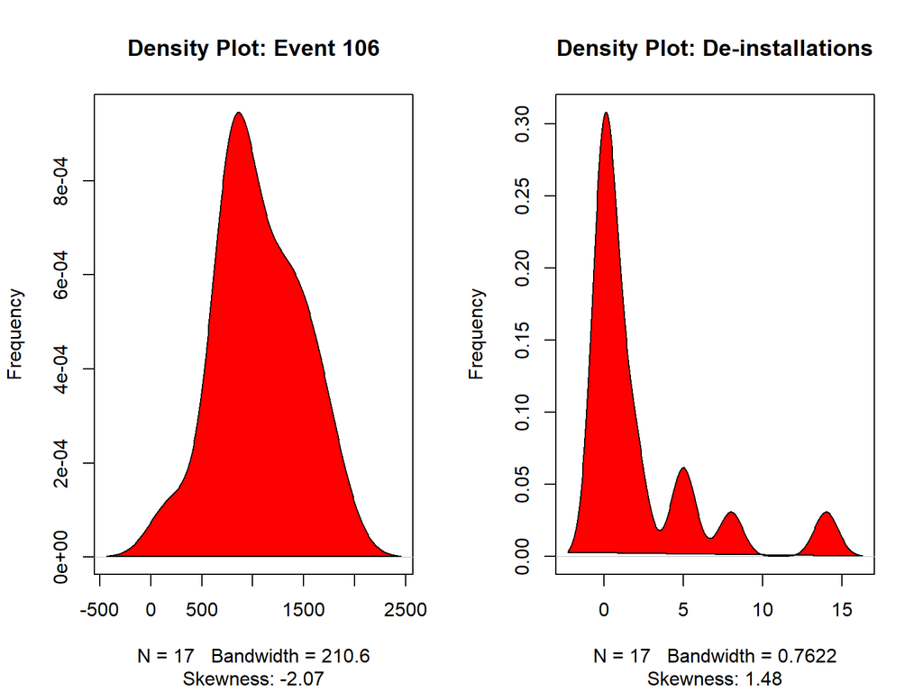

```
## [1] 0.5600051
```

```
##
## Call:
## lm(formula = X106 ~ De_Int, data = ALL)
##
## Residuals:
##    Min     1Q Median     3Q    Max
## -734.7 -174.7  -55.7  217.3  670.3
##
## Coefficients:
##             Estimate Std. Error t value Pr(>|t|)
## (Intercept)   927.70      99.83   9.293  1.3e-07 ***
## De_Int         60.24      23.01   2.618   0.0194 *
## ---
## Signif. codes:  0 '***' 0.001 '**' 0.01 '*' 0.05 '.' 0.1 ' ' 1
##
## Residual standard error: 352.8 on 15 degrees of freedom
## Multiple R-squared:  0.3136, Adjusted R-squared:  0.2678
## F-statistic: 6.853 on 1 and 15 DF,  p-value: 0.0194
```

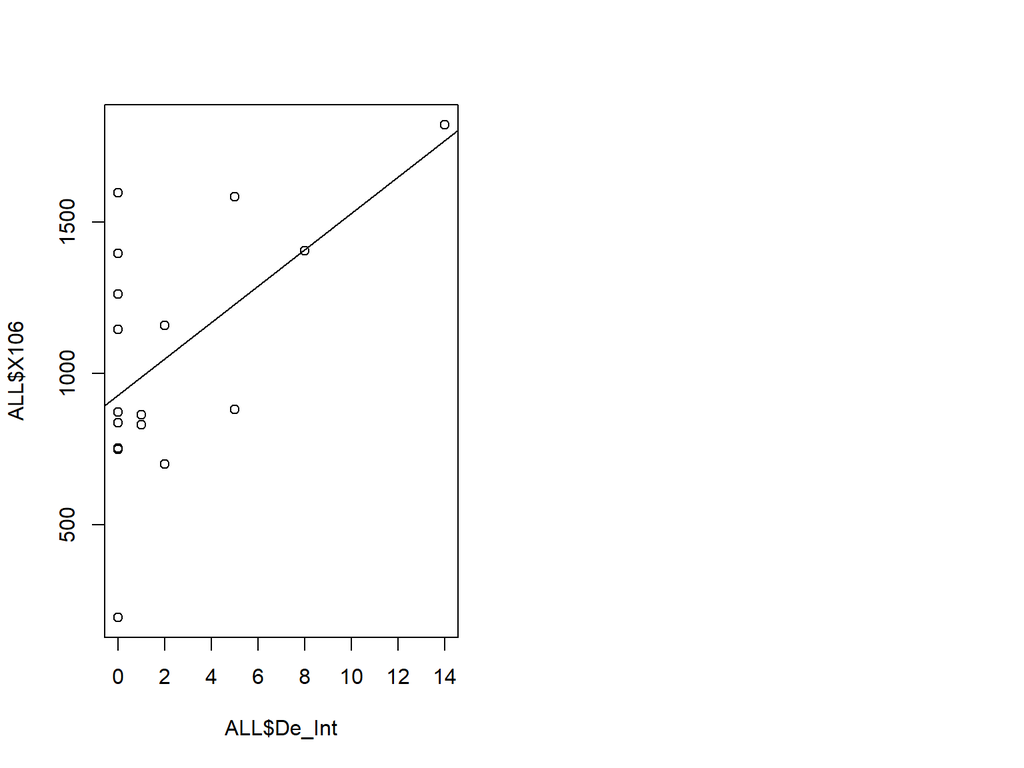

## Results

There was a correlation seen between gps event 15 and re-installations events and gps event 106 and de-installation events The final sample size was too small to make inferences from, some correlation can be seen. work order events are not normally distributed